# User Profile

[[edit on GitHub]](https://github.com/chef/automate/blob/master/components/docs-chef-io/content/automate/chef_automate_profile.md)

## Overview

Chef Automate users can manage their display name, date/time format, and password. Select the user icon in the top navigation bar, and select **Profile** from the drop-down menu.

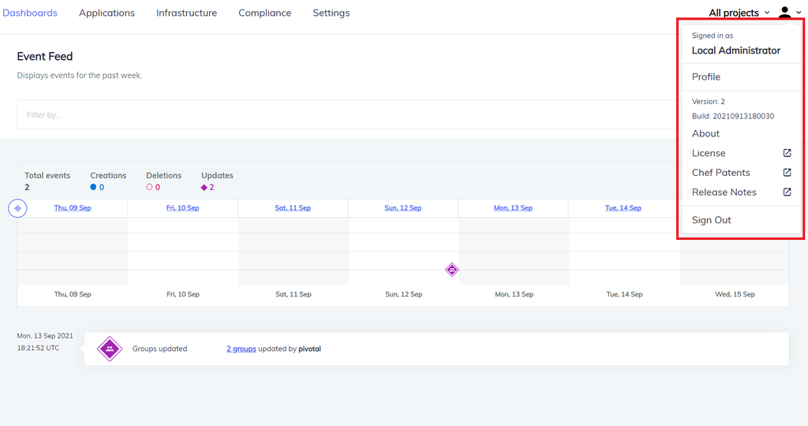

Select **Profile** to view the details. The **Details** tab updates the *Display Name* and the *Time Format*, whereas the **Reset Password** tab edits the password.

### Change a Display Name

Change the display name by entering any preferred name. Select **Save** to update the name.

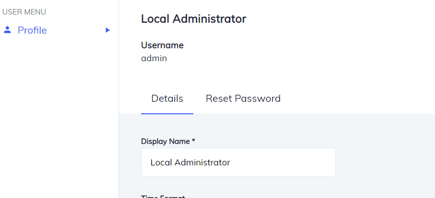

Every user needs a display name. An empty display name causes an error.

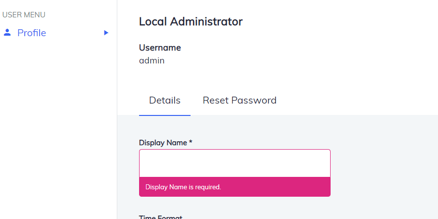

### Change the Date/Time Format

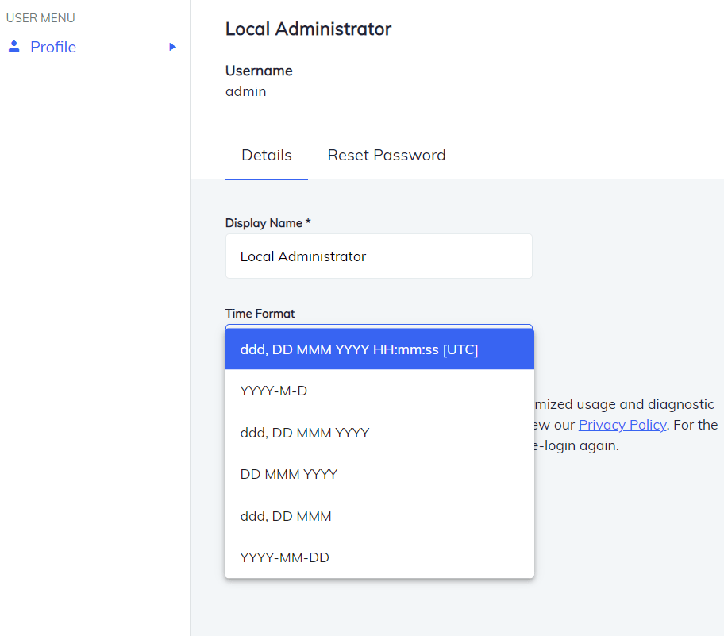

Select the date/time format and save to get the changes reflected in the interface.

### Reset Password

Reset the password of Chef Automate login from the **Reset Password** tab in Profile.

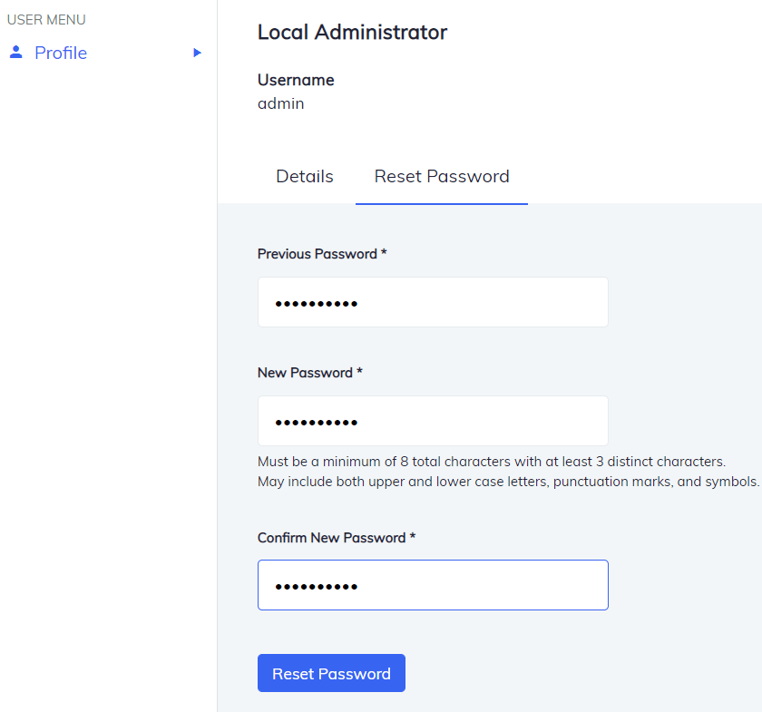

Insert the *Previous Password* and the *New Password* and select **Reset Password**.